# New RETRASCORE model using stepwise logistic regression

Model development: 2015-2019; temporal validation: 2020-2025

2026-09-28

# 1 Analysis design

Model development is performed exclusively with patients from 2015-2019. The 2020-2025 cohort is kept separate and is used only for temporal validation. No variable selection, coefficient estimation, point assignment, or calibration is performed with the 2020-2025 outcomes.

Following the Datanovia stepwise-logistic-regression workflow, the modelling procedure follows these steps:

1. Fit a full binomial logistic regression containing every predictor explicitly listed in the editable candidate-variable block below.
2. Apply bidirectional stepwise selection with `MASS::stepAIC()`, minimizing Akaike’s information criterion (AIC).
3. Use the refitted model returned by `stepAIC()` as the new multivariable logistic model.
4. Multiply every non-intercept coefficient by 2 and round it to the nearest integer, following the article.
5. Sum those same fixed points for every patient in both cohorts.
6. Estimate the score-to-mortality equation in 2015-2019 and apply it unchanged to both cohorts.
7. Compare observed and expected 30-day mortality in 2015-2019 and 2020-2025.

Variable selection and coefficient estimation use only the 2015-2019 cohort. The 2020-2025 outcomes are not examined by the stepwise procedure and no logistic regression is fitted in the temporal-validation cohort.

# 2 Candidate variables and cohorts

Every variable explicitly listed below enters the initial full model. To change the candidate set, add or remove a quoted column name in `candidate_variables`. Identifiers, the temporal split variable, outcomes, post-outcome variables, and the TRISS prediction are intentionally excluded.

```r
# EDIT THIS VECTOR TO CHANGE THE VARIABLES OFFERED TO stepAIC().
# Add a variable: write its column name in quotes followed by a comma.
# Remove a variable: delete its line (or place # at the start of that line).
# Every variable in this vector enters the initial full logistic model.
candidate_variables <- c(
  "genero_masculino",
  #"edad",
  "edad_categoria",
  "precoag",
  "atencion_prehospitalaria_medica",
  "iot_prehospitalaria",
  "trauma_penetrante",
  #"tipo_lesion",
  #"mecanismo_agrupado",
  "mecanismo_alto_riesgo",
  "pupilas",
  #"gcs_total",
  "gcs_menor_igual_8",
  #"ais_cabeza",
  "mais_cabeza",
  #"ais_torax",
  "mais_torax",
  #"ais_abdomen",
  "mais_abdomen",
  #"ais_ext_superior",
  "mais_ext_superior",
  #"ais_ext_inferior",
  "mais_ext_inferior",
  #"ais_externo",
  "mais_externo",
  "fallo_hemodinamico",
  "fallo_respiratorio",
  "coagulopatia_24h",
  "ventilacion_mecanica",
  "hemorragia_masiva"
)

# TRISS is an already fitted prognostic model and remains an external comparator;
# it is not offered to stepAIC() as a predictor of the new RETRASCORE.
comparison_variables <- c("probabilidad_muerte_triss")

protected_variables <- c(
  "id_fila", "historia", "registro", "hospital", "ano_trauma",
  "mortalidad_intrahospitalaria", "mortalidad_30d",
  "dias_hasta_muerte", "dias_estancia_uci",
  comparison_variables
)
if (!length(candidate_variables)) stop("The candidate-variable list is empty.")
if (anyDuplicated(candidate_variables)) {
  stop("The candidate-variable list contains duplicated names.")
}
invalid_candidates <- intersect(candidate_variables, protected_variables)
if (length(invalid_candidates)) {
  stop(
    "Identifiers, outcomes, post-outcome variables, temporal split variables, ",
    "and TRISS cannot be candidates: ", paste(invalid_candidates, collapse = ", ")
  )
}

required_variables <- c(
  "ano_trauma", "mortalidad_30d", candidate_variables
)
missing_variables <- setdiff(required_variables, names(cohort))
if (length(missing_variables)) {
  stop("Missing required variables: ", paste(missing_variables, collapse = ", "))
}

binary_variables <- c(
  "genero_masculino", "precoag", "atencion_prehospitalaria_medica",
  "iot_prehospitalaria", "trauma_penetrante", "mecanismo_alto_riesgo",
  "gcs_menor_igual_8", "mais_cabeza", "mais_torax", "mais_abdomen",
  "mais_ext_superior", "mais_ext_inferior", "mais_externo",
  "fallo_hemodinamico", "fallo_respiratorio", "coagulopatia_24h",
  "ventilacion_mecanica", "hemorragia_masiva"
)
check_binary <- function(x, variable_name) {
  values <- unique(stats::na.omit(x))
  if (!all(values %in% c(0, 1))) {
    stop("Variable '", variable_name, "' contains values other than 0, 1 or NA.")
  }
  as.integer(x)
}
for (variable_name in binary_variables) {
  cohort[[variable_name]] <- check_binary(cohort[[variable_name]], variable_name)
}
cohort$mortalidad_30d <- check_binary(
  cohort$mortalidad_30d, "mortalidad_30d"
)

valid_age_levels <- c("<50", "50-65", "66-75", ">75")
valid_pupil_levels <- c(
  "normal", "midriasis unilateral", "midriasis bilateral"
)
unexpected_age <- setdiff(
  unique(stats::na.omit(as.character(cohort$edad_categoria))),
  valid_age_levels
)
unexpected_pupils <- setdiff(
  unique(stats::na.omit(as.character(cohort$pupilas))),
  valid_pupil_levels
)
if (length(unexpected_age)) {
  stop("Unexpected age categories: ", paste(unexpected_age, collapse = ", "))
}
if (length(unexpected_pupils)) {
  stop("Unexpected pupil categories: ", paste(unexpected_pupils, collapse = ", "))
}

# Fix the references used by model.matrix and retain all levels after filtering.
cohort$edad_categoria <- factor(
  as.character(cohort$edad_categoria), levels = valid_age_levels
)
cohort$pupilas <- factor(
  as.character(cohort$pupilas), levels = valid_pupil_levels
)
cohort$tipo_lesion <- factor(cohort$tipo_lesion)
cohort$mecanismo_agrupado <- factor(cohort$mecanismo_agrupado)

eligible <- cohort %>%
  filter(!is.na(ano_trauma), ano_trauma >= 2015, ano_trauma <= 2025) %>%
  mutate(
    analysis_row_id = row_number(),
    period = ifelse(ano_trauma <= 2019, "Derivation 2015-2019", "Validation 2020-2025"),
    period = factor(
      period,
      levels = c("Derivation 2015-2019", "Validation 2020-2025")
    )
  )

derivation_all <- eligible %>% filter(period == "Derivation 2015-2019")
validation_all <- eligible %>% filter(period == "Validation 2020-2025")

# The full model and every candidate submodel use the same complete-case rows.
# This is essential because AIC values are not comparable across different
# numbers of observations.
model_complete_variables <- c("mortalidad_30d", candidate_variables)
derivation <- derivation_all[
  complete.cases(derivation_all[, model_complete_variables, drop = FALSE]),
  ,
  drop = FALSE
]

if (!nrow(derivation)) stop("No complete derivation cases were available.")
if (length(unique(derivation$mortalidad_30d)) != 2L) {
  stop("The derivation cohort must contain survivors and deaths.")
}

cohort_flow <- data.frame(
  Cohort = c("Derivation 2015-2019", "Validation 2020-2025"),
  Eligible = c(nrow(derivation_all), nrow(validation_all)),
  `Known outcome` = c(
    sum(!is.na(derivation_all$mortalidad_30d)),
    sum(!is.na(validation_all$mortalidad_30d))
  ),
  `Complete for all candidates` = c(
    sum(complete.cases(derivation_all[, model_complete_variables, drop = FALSE])),
    sum(complete.cases(validation_all[, model_complete_variables, drop = FALSE]))
  ),
  check.names = FALSE
)

knitr::kable(
  data.frame(Candidate = candidate_variables),
  caption = paste(
    length(candidate_variables),
    "candidate variables entered into the full logistic model"
  )
)
```

20 candidate variables entered into the full logistic model

| Candidate |
| --- |
| genero_masculino |
| edad_categoria |
| precoag |
| atencion_prehospitalaria_medica |
| iot_prehospitalaria |
| trauma_penetrante |
| mecanismo_alto_riesgo |
| pupilas |
| gcs_menor_igual_8 |
| mais_cabeza |
| mais_torax |
| mais_abdomen |
| mais_ext_superior |
| mais_ext_inferior |
| mais_externo |
| fallo_hemodinamico |
| fallo_respiratorio |
| coagulopatia_24h |
| ventilacion_mecanica |
| hemorragia_masiva |

```r
knitr::kable(cohort_flow, caption = "Initial cohort flow")
```

Initial cohort flow

| Cohort | Eligible | Known outcome | Complete for all candidates |
| --- | --- | --- | --- |
| Derivation 2015-2019 | 8821 | 8814 | 7936 |
| Validation 2020-2025 | 9095 | 9092 | 8172 |

# 3 Stepwise logistic regression

```r
full_model_formula <- reformulate(
  candidate_variables,
  response = "mortalidad_30d"
)
full_model <- glm(
  full_model_formula,
  data = derivation,
  family = binomial(link = "logit"),
  na.action = na.fail
)
if (!full_model$converged) stop("The full logistic regression did not converge.")
if (anyNA(coef(full_model))) {
  stop("The full logistic regression contains non-estimable coefficients.")
}

# Both-direction selection starts from the full model. At each step, stepAIC()
# considers adding or removing a term and retains a change only when it lowers
# AIC. The returned object is already refitted and is the new model used below.
stepwise_model <- MASS::stepAIC(
  full_model,
  direction = "both",
  trace = FALSE
)
if (!stepwise_model$converged) {
  stop("The stepwise-selected logistic regression did not converge.")
}
if (anyNA(coef(stepwise_model))) {
  stop("The stepwise-selected model contains non-estimable coefficients.")
}

selected_variables <- attr(terms(stepwise_model), "term.labels")
if (!length(selected_variables)) {
  stop("Stepwise selection produced an intercept-only model.")
}

stepwise_path <- stepwise_model$anova
names(stepwise_path) <- make.names(names(stepwise_path), unique = TRUE)
selection_summary <- data.frame(
  Derivation_N = nrow(derivation),
  Deaths = sum(derivation$mortalidad_30d),
  Candidate_variables = length(candidate_variables),
  Selected_variables = length(selected_variables),
  Full_model_AIC = AIC(full_model),
  Stepwise_model_AIC = AIC(stepwise_model),
  AIC_reduction = AIC(full_model) - AIC(stepwise_model)
)

utils::write.csv(
  stepwise_path,
  file.path(output_dir, "stepwise_selection_path.csv"),
  row.names = FALSE,
  fileEncoding = "UTF-8"
)

knitr::kable(selection_summary, digits = 3, caption = "Stepwise selection summary")
```

Stepwise selection summary

| Derivation_N | Deaths | Candidate_variables | Selected_variables | Full_model_AIC | Stepwise_model_AIC | AIC_reduction |
| --- | --- | --- | --- | --- | --- | --- |
| 7936 | 1036 | 20 | 16 | 3374.957 | 3369.111 | 5.846 |

```r
knitr::kable(
  data.frame(Selected_variable = selected_variables),
  caption = "Variables retained by bidirectional AIC selection"
)
```

Variables retained by bidirectional AIC selection

| Selected_variable |
| --- |
| genero_masculino |
| edad_categoria |
| precoag |
| iot_prehospitalaria |
| mecanismo_alto_riesgo |
| pupilas |
| gcs_menor_igual_8 |
| mais_cabeza |
| mais_torax |
| mais_ext_superior |
| mais_externo |
| fallo_hemodinamico |
| fallo_respiratorio |
| coagulopatia_24h |
| ventilacion_mecanica |
| hemorragia_masiva |

```r
knitr::kable(
  stepwise_path,
  digits = 3,
  caption = "AIC path followed by stepAIC"
)
```

AIC path followed by stepAIC

| Step | Df | Deviance | Resid..Df | Resid..Dev | AIC |
| --- | --- | --- | --- | --- | --- |
|  | NA | NA | 7912 | 3326.957 | 3374.957 |
| - mais_abdomen | 1 | 0.006 | 7913 | 3326.962 | 3372.962 |
| - trauma_penetrante | 1 | 0.103 | 7914 | 3327.065 | 3371.065 |
| - atencion_prehospitalaria_medica | 1 | 0.138 | 7915 | 3327.203 | 3369.203 |
| - mais_ext_inferior | 1 | 1.907 | 7916 | 3329.111 | 3369.111 |

## 3.1 Variable-inclusion plot

This plot is the logistic-regression analogue of a `leaps::regsubsets()` plot. Rows are complete model terms, including categorical variables as single terms; columns are the successive models visited by `stepAIC()`. Because the outcome is binary, model quality is shown with AIC rather than adjusted R-squared.

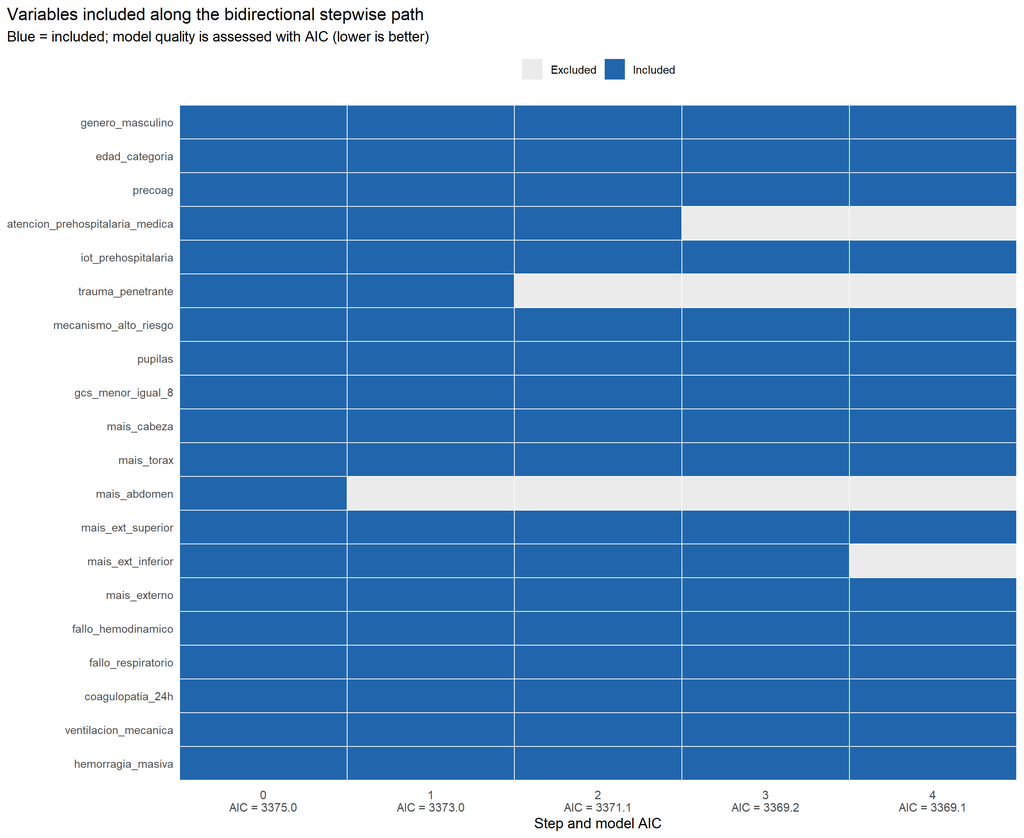

```r
step_actions <- trimws(as.character(stepwise_path$Step))
step_actions[is.na(step_actions)] <- ""

included_at_step <- vector("list", nrow(stepwise_path))
current_variables <- candidate_variables
included_at_step[[1]] <- current_variables

if (nrow(stepwise_path) > 1L) {
  for (step_index in 2:nrow(stepwise_path)) {
    action <- step_actions[step_index]
    variable_name <- trimws(sub("^[+-]\\s*", "", action))
    if (startsWith(action, "-")) {
      current_variables <- setdiff(current_variables, variable_name)
    } else if (startsWith(action, "+")) {
      current_variables <- union(current_variables, variable_name)
    }
    included_at_step[[step_index]] <- current_variables
  }
}

step_labels <- ifelse(
  seq_len(nrow(stepwise_path)) == 1L,
  "Initial full model",
  step_actions
)
aic_labels <- paste0(
  seq_len(nrow(stepwise_path)) - 1L,
  "\nAIC = ", formatC(stepwise_path$AIC, digits = 1, format = "f")
)

stepwise_inclusion <- do.call(
  rbind,
  lapply(seq_len(nrow(stepwise_path)), function(step_index) {
    data.frame(
      Step_index = step_index - 1L,
      Step = step_labels[step_index],
      AIC = stepwise_path$AIC[step_index],
      Variable = candidate_variables,
      Included = candidate_variables %in% included_at_step[[step_index]],
      stringsAsFactors = FALSE
    )
  })
)
stepwise_inclusion$Variable <- factor(
  stepwise_inclusion$Variable,
  levels = rev(candidate_variables)
)

stepwise_inclusion_plot <- ggplot(
  stepwise_inclusion,
  aes(x = Step_index, y = Variable, fill = Included)
) +
  geom_tile(color = "white", linewidth = 0.35) +
  scale_fill_manual(
    values = c(`FALSE` = "grey92", `TRUE` = "#2166AC"),
    labels = c(`FALSE` = "Excluded", `TRUE` = "Included"),
    name = NULL
  ) +
  scale_x_continuous(
    breaks = seq_len(nrow(stepwise_path)) - 1L,
    labels = aic_labels,
    expand = c(0, 0)
  ) +
  labs(
    title = "Variables included along the bidirectional stepwise path",
    subtitle = "Blue = included; model quality is assessed with AIC (lower is better)",
    x = "Step and model AIC",
    y = NULL
  ) +
  theme_minimal(base_size = 11) +
  theme(
    panel.grid = element_blank(),
    axis.text.x = element_text(size = 9),
    legend.position = "top",
    plot.title.position = "plot"
  )

print(stepwise_inclusion_plot)
```

```r
ggsave(
  file.path(output_dir, "stepwise_variable_inclusion.png"),
  stepwise_inclusion_plot,
  width = 11,
  height = max(7, 0.30 * length(candidate_variables) + 2),
  dpi = 300
)
utils::write.csv(
  stepwise_inclusion,
  file.path(output_dir, "stepwise_variable_inclusion.csv"),
  row.names = FALSE,
  fileEncoding = "UTF-8"
)
```

# 4 Logistic regression in 2015-2019

The model returned by `stepAIC()` is already refitted on the 2015-2019 derivation data. It is used unchanged for coefficient reporting and all subsequent score construction.

```r
model_formula <- reformulate(selected_variables, response = "mortalidad_30d")
logistic_model <- stepwise_model
if (!logistic_model$converged) stop("The logistic regression did not converge.")
if (anyNA(coef(logistic_model))) {
  stop("The logistic regression contains non-estimable coefficients.")
}

coefficient_matrix <- summary(logistic_model)$coefficients
coefficient_table <- data.frame(
  Term = rownames(coefficient_matrix),
  Beta = coefficient_matrix[, "Estimate"],
  `Standard error` = coefficient_matrix[, "Std. Error"],
  `P value` = coefficient_matrix[, "Pr(>|z|)"],
  OR = exp(coefficient_matrix[, "Estimate"]),
  `OR 95% CI lower` = exp(
    coefficient_matrix[, "Estimate"] -
      1.96 * coefficient_matrix[, "Std. Error"]
  ),
  `OR 95% CI upper` = exp(
    coefficient_matrix[, "Estimate"] +
      1.96 * coefficient_matrix[, "Std. Error"]
  ),
  check.names = FALSE,
  row.names = NULL
)

utils::write.csv(
  coefficient_table,
  file.path(output_dir, "logistic_regression_coefficients.csv"),
  row.names = FALSE,
  fileEncoding = "UTF-8"
)
knitr::kable(
  coefficient_table,
  digits = 4,
  caption = "Logistic regression fitted only in 2015-2019"
)
```

Logistic regression fitted only in 2015-2019

| Term | Beta | Standard error | P value | OR | OR 95% CI lower | OR 95% CI upper |
| --- | --- | --- | --- | --- | --- | --- |
| (Intercept) | -5.9937 | 0.2011 | 0.0000 | 0.0025 | 0.0017 | 0.0037 |
| genero_masculino | 0.2238 | 0.1070 | 0.0364 | 1.2509 | 1.0142 | 1.5427 |
| edad_categoria50-65 | 0.9212 | 0.1299 | 0.0000 | 2.5123 | 1.9474 | 3.2409 |
| edad_categoria66-75 | 1.6399 | 0.1513 | 0.0000 | 5.1544 | 3.8315 | 6.9341 |
| edad_categoria>75 | 2.5187 | 0.1525 | 0.0000 | 12.4126 | 9.2057 | 16.7366 |
| precoag | 0.4280 | 0.1171 | 0.0003 | 1.5341 | 1.2195 | 1.9299 |
| iot_prehospitalaria | 0.2357 | 0.1187 | 0.0471 | 1.2658 | 1.0030 | 1.5975 |
| mecanismo_alto_riesgo | 0.5755 | 0.1046 | 0.0000 | 1.7779 | 1.4484 | 2.1825 |
| pupilasmidriasis unilateral | 1.1996 | 0.1258 | 0.0000 | 3.3188 | 2.5934 | 4.2470 |
| pupilasmidriasis bilateral | 3.2858 | 0.1892 | 0.0000 | 26.7316 | 18.4501 | 38.7301 |
| gcs_menor_igual_8 | 1.0592 | 0.1237 | 0.0000 | 2.8841 | 2.2633 | 3.6752 |
| mais_cabeza | 0.9476 | 0.1191 | 0.0000 | 2.5796 | 2.0427 | 3.2577 |
| mais_torax | -0.1930 | 0.1088 | 0.0761 | 0.8245 | 0.6662 | 1.0204 |
| mais_ext_superior | -0.5175 | 0.2582 | 0.0451 | 0.5960 | 0.3593 | 0.9887 |
| mais_externo | 0.9688 | 0.3551 | 0.0064 | 2.6349 | 1.3136 | 5.2852 |
| fallo_hemodinamico | 1.0780 | 0.1119 | 0.0000 | 2.9387 | 2.3598 | 3.6597 |
| fallo_respiratorio | 0.6612 | 0.1208 | 0.0000 | 1.9371 | 1.5288 | 2.4543 |
| coagulopatia_24h | 0.6493 | 0.1229 | 0.0000 | 1.9142 | 1.5045 | 2.4355 |
| ventilacion_mecanica | 0.4668 | 0.1202 | 0.0001 | 1.5949 | 1.2602 | 2.0184 |
| hemorragia_masiva | 0.7740 | 0.1651 | 0.0000 | 2.1684 | 1.5688 | 2.9971 |

# 5 Fixed integer score

Following the article, each non-intercept regression coefficient is multiplied by 2 and rounded to the nearest integer. This creates one fixed point system. The same points are applied to patients in both cohorts.

```r
round_nearest_integer <- function(x) {
  sign(x) * floor(abs(x) + 0.5)
}

regression_betas <- coef(logistic_model)[-1]
score_points <- setNames(
  as.integer(round_nearest_integer(2 * regression_betas)),
  names(regression_betas)
)
points_table <- data.frame(
  Term = names(regression_betas),
  Beta = as.numeric(regression_betas),
  `Beta multiplied by 2` = 2 * as.numeric(regression_betas),
  Points = as.integer(score_points),
  check.names = FALSE,
  row.names = NULL
)
score_formula <- reformulate(selected_variables)

reference_rows <- lapply(names(logistic_model$xlevels), function(variable_name) {
  data.frame(
    Term = paste0(
      variable_name, logistic_model$xlevels[[variable_name]][1], " (reference)"
    ),
    Beta = 0,
    `Beta multiplied by 2` = 0,
    Points = 0L,
    check.names = FALSE
  )
})
points_table_display <- if (length(reference_rows)) {
  rbind(points_table, do.call(rbind, reference_rows))
} else points_table

calculate_score <- function(data) {
  # Use a predictor-only formula so rows with an unknown outcome are not
  # removed or shifted while assigning patient-level scores.
  design_matrix <- model.matrix(score_formula, data = data)[, -1, drop = FALSE]
  missing_columns <- setdiff(names(score_points), colnames(design_matrix))
  if (length(missing_columns)) {
    stop("Missing score columns: ", paste(missing_columns, collapse = ", "))
  }
  design_matrix <- design_matrix[, names(score_points), drop = FALSE]
  as.integer(drop(design_matrix %*% score_points))
}

# Score every patient with all selected predictors, whether or not the outcome
# is known. Missing predictors remain explicit and are never assigned zero.
score_available <- complete.cases(
  eligible[, selected_variables, drop = FALSE]
)
eligible$new_score <- NA_integer_
eligible$new_score[score_available] <- calculate_score(
  eligible[score_available, , drop = FALSE]
)

# Estimate the score-to-mortality equation only in the derivation cases used to
# fit the logistic regression, then freeze it for both cohorts.
derivation$new_score <- calculate_score(derivation)
score_probability_model <- glm(
  mortalidad_30d ~ new_score,
  data = derivation,
  family = binomial(link = "logit")
)
if (!score_probability_model$converged) {
  stop("The score-to-mortality model did not converge.")
}

eligible$expected_mortality <- NA_real_
eligible$expected_mortality[score_available] <- predict(
  score_probability_model,
  newdata = data.frame(new_score = eligible$new_score[score_available]),
  type = "response"
)

utils::write.csv(
  points_table_display,
  file.path(output_dir, "new_score_points.csv"),
  row.names = FALSE,
  fileEncoding = "UTF-8"
)
knitr::kable(
  points_table_display,
  digits = c(0, 4, 4, 0),
  caption = "Fixed point system derived in 2015-2019 and applied to both cohorts"
)
```

Fixed point system derived in 2015-2019 and applied to both cohorts

| Term | Beta | Beta multiplied by 2 | Points |
| --- | --- | --- | --- |
| genero_masculino | 0.2238 | 0.4477 | 0 |
| edad_categoria50-65 | 0.9212 | 1.8424 | 2 |
| edad_categoria66-75 | 1.6399 | 3.2797 | 3 |
| edad_categoria>75 | 2.5187 | 5.0374 | 5 |
| precoag | 0.4280 | 0.8559 | 1 |
| iot_prehospitalaria | 0.2357 | 0.4714 | 0 |
| mecanismo_alto_riesgo | 0.5755 | 1.1509 | 1 |
| pupilasmidriasis unilateral | 1.1996 | 2.3992 | 2 |
| pupilasmidriasis bilateral | 3.2858 | 6.5717 | 7 |
| gcs_menor_igual_8 | 1.0592 | 2.1184 | 2 |
| mais_cabeza | 0.9476 | 1.8953 | 2 |
| mais_torax | -0.1930 | -0.3860 | 0 |
| mais_ext_superior | -0.5175 | -1.0350 | -1 |
| mais_externo | 0.9688 | 1.9377 | 2 |
| fallo_hemodinamico | 1.0780 | 2.1560 | 2 |
| fallo_respiratorio | 0.6612 | 1.3223 | 1 |
| coagulopatia_24h | 0.6493 | 1.2986 | 1 |
| ventilacion_mecanica | 0.4668 | 0.9336 | 1 |
| hemorragia_masiva | 0.7740 | 1.5479 | 2 |
| edad_categoria<50 (reference) | 0.0000 | 0.0000 | 0 |
| pupilasnormal (reference) | 0.0000 | 0.0000 | 0 |

```r
score_equation <- data.frame(
  Component = c("Intercept", "Coefficient per score point"),
  Estimate = unname(coef(score_probability_model))
)
knitr::kable(
  score_equation,
  digits = 5,
  caption = "2015-2019 equation converting the fixed score to expected mortality"
)
```

2015-2019 equation converting the fixed score to expected mortality

| Component | Estimate |
| --- | --- |
| Intercept | -5.81156 |
| Coefficient per score point | 0.51395 |

For total score `S`, expected mortality is calculated as

$$P(\text{30-day death}) = \frac{1}{1 + \exp[-(a + bS)]},$$

where `a` and `b` are estimated above using only 2015-2019.

# 6 Observed versus expected mortality

The 2015-2019 comparison uses the complete derivation cases used for the full and stepwise regressions. The 2020-2025 comparison uses patients with a calculable score and a known 30-day outcome.

```r
derivation_evaluation <- eligible %>%
  filter(
    analysis_row_id %in% derivation$analysis_row_id,
    !is.na(mortalidad_30d),
    !is.na(expected_mortality)
  )
validation_evaluation <- eligible %>%
  filter(
    period == "Validation 2020-2025",
    !is.na(mortalidad_30d),
    !is.na(expected_mortality)
  )

summarise_observed_expected <- function(data, cohort_name) {
  deaths <- sum(data$mortalidad_30d)
  patients <- nrow(data)
  observed_ci <- stats::binom.test(deaths, patients)$conf.int
  data.frame(
    Cohort = cohort_name,
    Patients = patients,
    Deaths = deaths,
    `Observed mortality (%)` = 100 * deaths / patients,
    `Observed 95% CI lower` = 100 * observed_ci[1],
    `Observed 95% CI upper` = 100 * observed_ci[2],
    `Expected deaths` = sum(data$expected_mortality),
    `Expected mortality (%)` = 100 * mean(data$expected_mortality),
    `Observed/expected deaths` = deaths / sum(data$expected_mortality),
    check.names = FALSE
  )
}

observed_expected_summary <- rbind(
  summarise_observed_expected(derivation_evaluation, "2015-2019"),
  summarise_observed_expected(validation_evaluation, "2020-2025")
)

utils::write.csv(
  observed_expected_summary,
  file.path(output_dir, "observed_vs_expected_mortality.csv"),
  row.names = FALSE,
  fileEncoding = "UTF-8"
)
knitr::kable(
  observed_expected_summary,
  digits = c(0, 0, 0, 2, 2, 2, 1, 2, 3),
  caption = "Observed and expected 30-day mortality using the same fixed score"
)
```

Observed and expected 30-day mortality using the same fixed score

| Cohort | Patients | Deaths | Observed mortality (%) | Observed 95% CI lower | Observed 95% CI upper | Expected deaths | Expected mortality (%) | Observed/expected deaths |
| --- | --- | --- | --- | --- | --- | --- | --- | --- |
| 2015-2019 | 7936 | 1036 | 13.05 | 12.32 | 13.82 | 1036.0 | 13.05 | 1.000 |
| 2020-2025 | 8450 | 1013 | 11.99 | 11.30 | 12.70 | 968.2 | 11.46 | 1.046 |

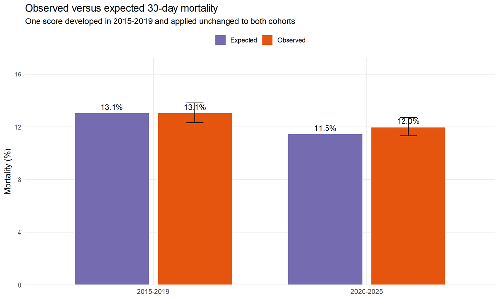

Observed and expected mortality in the derivation and temporal-validation cohorts.

## 6.1 Observed and predicted mortality by risk group

The fixed new score is divided using the same point thresholds as the published RETRASCORE presentation. These labels describe score bands; the underlying points and expected mortality equation remain those developed exclusively in 2015-2019 for the new model.

```r
evaluation_data <- bind_rows(
  derivation_evaluation %>% mutate(Cohort = "2015-2019"),
  validation_evaluation %>% mutate(Cohort = "2020-2025")
)

risk_group_levels <- c(
  "Very low (<5)",
  "Low (5-6)",
  "Medium (7-8)",
  "High (9-11)",
  "Very high (12-13)",
  "Extreme (14+)"
)
evaluation_data$risk_group <- cut(
  evaluation_data$new_score,
  breaks = c(-Inf, 4, 6, 8, 11, 13, Inf),
  labels = risk_group_levels,
  ordered_result = TRUE
)

mortality_by_risk_group <- evaluation_data %>%
  group_by(Cohort, risk_group, .drop = FALSE) %>%
  summarise(
    Patients = n(),
    Deaths = sum(mortalidad_30d),
    `Observed mortality (%)` = 100 * mean(mortalidad_30d),
    `Predicted mortality (%)` = 100 * mean(expected_mortality),
    .groups = "drop"
  ) %>%
  rowwise() %>%
  mutate(
    `95% CI lower` = if (Patients > 0) {
      100 * stats::binom.test(Deaths, Patients)$conf.int[1]
    } else NA_real_,
    `95% CI upper` = if (Patients > 0) {
      100 * stats::binom.test(Deaths, Patients)$conf.int[2]
    } else NA_real_
  ) %>%
  ungroup() %>%
  rename(period = Cohort)

utils::write.csv(
  mortality_by_risk_group,
  file.path(output_dir, "observed_vs_predicted_by_risk_group.csv"),
  row.names = FALSE,
  fileEncoding = "UTF-8"
)

knitr::kable(
  mortality_by_risk_group,
  digits = c(0, 0, 0, 0, 2, 2, 2, 2),
  caption = "Observed and predicted mortality by new-score risk group"
)
```

Observed and predicted mortality by new-score risk group

| period | risk_group | Patients | Deaths | Observed mortality (%) | Predicted mortality (%) | 95% CI lower | 95% CI upper |
| --- | --- | --- | --- | --- | --- | --- | --- |
| 2015-2019 | Very low (<5) | 4009 | 19 | 0.47 | 0.96 | 0.29 | 0.74 |
| 2015-2019 | Low (5-6) | 1383 | 72 | 5.21 | 4.91 | 4.10 | 6.51 |
| 2015-2019 | Medium (7-8) | 1003 | 135 | 13.46 | 12.31 | 11.41 | 15.73 |
| 2015-2019 | High (9-11) | 868 | 308 | 35.48 | 31.90 | 32.30 | 38.77 |
| 2015-2019 | Very high (12-13) | 296 | 174 | 58.78 | 63.97 | 52.94 | 64.45 |
| 2015-2019 | Extreme (14+) | 377 | 328 | 87.00 | 90.13 | 83.18 | 90.23 |
| 2020-2025 | Very low (<5) | 4530 | 21 | 0.46 | 0.99 | 0.29 | 0.71 |
| 2020-2025 | Low (5-6) | 1467 | 81 | 5.52 | 4.87 | 4.41 | 6.82 |
| 2020-2025 | Medium (7-8) | 1014 | 156 | 15.38 | 12.43 | 13.22 | 17.75 |
| 2020-2025 | High (9-11) | 873 | 316 | 36.20 | 31.85 | 33.00 | 39.48 |
| 2020-2025 | Very high (12-13) | 231 | 152 | 65.80 | 64.11 | 59.29 | 71.90 |
| 2020-2025 | Extreme (14+) | 335 | 287 | 85.67 | 89.49 | 81.46 | 89.24 |

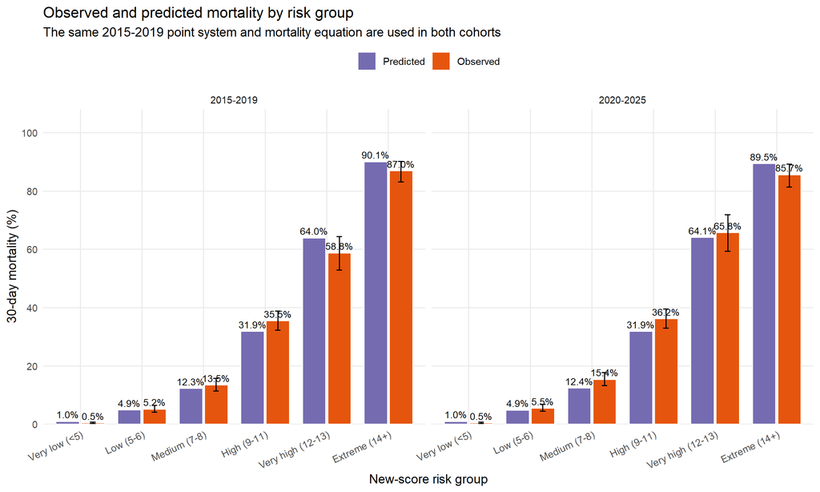

Observed and predicted 30-day mortality by new-score risk group.

## 6.2 Observed and expected mortality by exact score

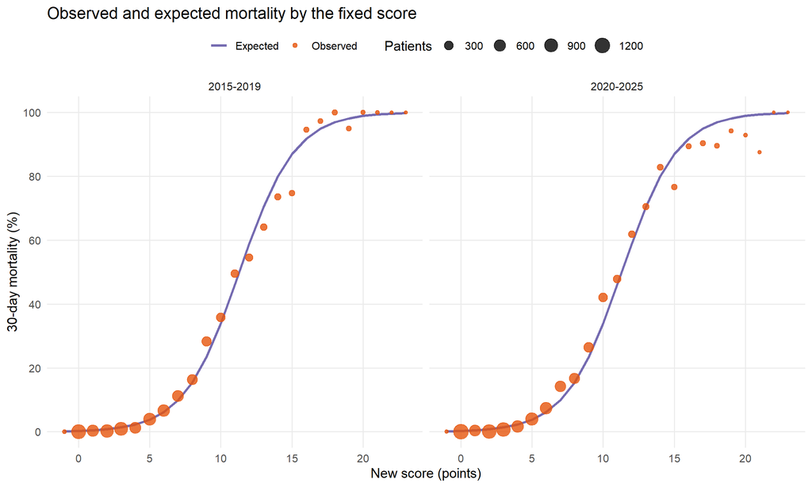

```r
mortality_by_score <- evaluation_data %>%
  group_by(Cohort, new_score) %>%
  summarise(
    Patients = n(),
    Deaths = sum(mortalidad_30d),
    `Observed mortality (%)` = 100 * mean(mortalidad_30d),
    `Expected mortality (%)` = 100 * mean(expected_mortality),
    .groups = "drop"
  )

utils::write.csv(
  mortality_by_score,
  file.path(output_dir, "observed_vs_expected_by_score.csv"),
  row.names = FALSE,
  fileEncoding = "UTF-8"
)

score_plot_data <- rbind(
  data.frame(
    Cohort = mortality_by_score$Cohort,
    new_score = mortality_by_score$new_score,
    Patients = mortality_by_score$Patients,
    Mortality = "Expected",
    Percent = mortality_by_score$`Expected mortality (%)`
  ),
  data.frame(
    Cohort = mortality_by_score$Cohort,
    new_score = mortality_by_score$new_score,
    Patients = mortality_by_score$Patients,
    Mortality = "Observed",
    Percent = mortality_by_score$`Observed mortality (%)`
  )
)

mortality_score_plot <- ggplot(
  score_plot_data,
  aes(x = new_score, y = Percent, colour = Mortality)
) +
  geom_line(
    data = subset(score_plot_data, Mortality == "Expected"),
    linewidth = 1
  ) +
  geom_point(
    data = subset(score_plot_data, Mortality == "Observed"),
    aes(size = Patients), alpha = 0.80
  ) +
  facet_wrap(~ Cohort) +
  scale_colour_manual(values = c("Expected" = "#756BB1", "Observed" = "#E6550D")) +
  scale_y_continuous(limits = c(0, 100), breaks = seq(0, 100, 20)) +
  labs(
    title = "Observed and expected mortality by the fixed score",
    x = "New score (points)", y = "30-day mortality (%)",
    colour = NULL, size = "Patients"
  ) +
  theme_minimal(base_size = 12) +
  theme(panel.grid.minor = element_blank(), legend.position = "top")

mortality_score_plot
```

```r
ggsave(
  file.path(output_dir, "observed_vs_expected_by_score.png"),
  mortality_score_plot, width = 11, height = 6.5, dpi = 180
)
```

# 7 Score performance

```r
evaluate_score <- function(data, cohort_name) {
  outcome <- data$mortalidad_30d
  probability <- data$expected_mortality
  roc_object <- pROC::roc(
    outcome, probability, levels = c(0, 1), direction = "<", quiet = TRUE
  )
  auc_ci <- as.numeric(pROC::ci.auc(roc_object, method = "delong"))
  lp <- qlogis(pmin(pmax(probability, 1e-12), 1 - 1e-12))
  intercept_model <- glm(outcome ~ 1, offset = lp, family = binomial())
  slope_model <- glm(outcome ~ lp, family = binomial())
  data.frame(
    Cohort = cohort_name,
    N = length(outcome),
    AUROC = as.numeric(pROC::auc(roc_object)),
    `AUROC 95% CI lower` = auc_ci[1],
    `AUROC 95% CI upper` = auc_ci[3],
    Brier = mean((outcome - probability)^2),
    `Calibration intercept` = unname(coef(intercept_model)[1]),
    `Calibration slope` = unname(coef(slope_model)[2]),
    check.names = FALSE
  )
}

score_performance <- rbind(
  evaluate_score(derivation_evaluation, "2015-2019"),
  evaluate_score(validation_evaluation, "2020-2025")
)
utils::write.csv(
  score_performance,
  file.path(output_dir, "model_validation_metrics.csv"),
  row.names = FALSE,
  fileEncoding = "UTF-8"
)

performance_display <- score_performance
performance_display$`AUROC (95% CI)` <- sprintf(
  "%.3f (%.3f-%.3f)", performance_display$AUROC,
  performance_display$`AUROC 95% CI lower`,
  performance_display$`AUROC 95% CI upper`
)
performance_display <- performance_display[, c(
  "Cohort", "N", "AUROC (95% CI)", "Brier",
  "Calibration intercept", "Calibration slope"
)]
knitr::kable(
  performance_display,
  digits = c(0, 0, 0, 3, 3, 3),
  caption = "Performance of the fixed integer score in both cohorts"
)
```

Performance of the fixed integer score in both cohorts

| Cohort | N | AUROC (95% CI) | Brier | Calibration intercept | Calibration slope |
| --- | --- | --- | --- | --- | --- |
| 2015-2019 | 7936 | 0.926 (0.919-0.934) | 0.064 | 0.00 | 1.000 |
| 2020-2025 | 8450 | 0.926 (0.919-0.934) | 0.061 | 0.09 | 1.009 |

# 8 Patient-level scores and saved model

```r
identifier_candidates <- c("id_fila", "historia", "registro", "hospital")
identifier_variables <- intersect(identifier_candidates, names(eligible))
patient_predictions <- eligible %>%
  select(
    analysis_row_id, all_of(identifier_variables), ano_trauma,
    cohort = period, mortalidad_30d, new_score, expected_mortality
  ) %>%
  mutate(score_available = !is.na(new_score), .after = mortalidad_30d)

utils::write.csv(
  patient_predictions,
  file.path(output_dir, "patient_scores_and_predictions.csv"),
  row.names = FALSE,
  na = "",
  fileEncoding = "UTF-8"
)

model_bundle <- list(
  analysis = paste(
    paste0("Full ", length(candidate_variables), "-variable logistic regression"),
    "followed by bidirectional",
    "AIC stepwise selection in 2015-2019"
  ),
  derivation_years = 2015:2019,
  validation_years = 2020:2025,
  selection_method = "MASS::stepAIC",
  selection_direction = "both",
  selection_criterion = "AIC",
  candidate_variables = candidate_variables,
  selected_variables = selected_variables,
  full_model_formula = full_model_formula,
  full_model = full_model,
  stepwise_selection_path = stepwise_path,
  logistic_formula = model_formula,
  logistic_model = logistic_model,
  integer_points = score_points,
  score_probability_model = score_probability_model
)
saveRDS(
  model_bundle,
  file.path(output_dir, "new_stepwise_logistic_model.rds")
)

saved_files <- data.frame(
  File = c(
    "stepwise_selection_path.csv",
    "stepwise_variable_inclusion.csv",
    "logistic_regression_coefficients.csv",
    "new_score_points.csv",
    "observed_vs_expected_mortality.csv",
    "observed_vs_predicted_by_risk_group.csv",
    "observed_vs_expected_by_score.csv",
    "model_validation_metrics.csv",
    "patient_scores_and_predictions.csv",
    "new_stepwise_logistic_model.rds",
    "stepwise_variable_inclusion.png",
    "observed_vs_expected_mortality.png",
    "observed_vs_predicted_by_risk_group.png",
    "observed_vs_expected_by_score.png"
  ),
  Purpose = c(
    paste0(
      "Bidirectional AIC selection path from the full ",
      length(candidate_variables), "-variable model"
    ),
    "Variables included at each step and the corresponding model AIC",
    "Stepwise-selected logistic regression fitted in 2015-2019",
    "Fixed article-style point table",
    "Overall observed and expected mortality",
    "Observed and predicted mortality by six risk groups",
    "Observed and expected mortality for each score",
    "Discrimination and calibration in both cohorts",
    "Patient-level fixed scores and expected mortality",
    "Reusable fitted model, points, and metadata",
    "Variable-inclusion heatmap for the bidirectional AIC path",
    "Overall mortality comparison plot",
    "Risk-group mortality comparison plot",
    "Mortality comparison by score"
  )
)
knitr::kable(saved_files, caption = "Files saved by this report")
```

Files saved by this report

| File | Purpose |
| --- | --- |
| stepwise_selection_path.csv | Bidirectional AIC selection path from the full 20-variable model |
| stepwise_variable_inclusion.csv | Variables included at each step and the corresponding model AIC |
| logistic_regression_coefficients.csv | Stepwise-selected logistic regression fitted in 2015-2019 |
| new_score_points.csv | Fixed article-style point table |
| observed_vs_expected_mortality.csv | Overall observed and expected mortality |
| observed_vs_predicted_by_risk_group.csv | Observed and predicted mortality by six risk groups |
| observed_vs_expected_by_score.csv | Observed and expected mortality for each score |
| model_validation_metrics.csv | Discrimination and calibration in both cohorts |
| patient_scores_and_predictions.csv | Patient-level fixed scores and expected mortality |
| new_stepwise_logistic_model.rds | Reusable fitted model, points, and metadata |
| stepwise_variable_inclusion.png | Variable-inclusion heatmap for the bidirectional AIC path |
| observed_vs_expected_mortality.png | Overall mortality comparison plot |
| observed_vs_predicted_by_risk_group.png | Risk-group mortality comparison plot |
| observed_vs_expected_by_score.png | Mortality comparison by score |

# 9 Reproducibility notes

- Missing candidate values are handled by complete-case analysis; no value is imputed and no missing predictor is interpreted as zero.
- All 20 explicitly listed predictor variables enter the initial full logistic model. The bidirectional `stepAIC()` search removes or re-adds complete model terms, including categorical predictors as whole terms.
- All candidate models are fitted to the same complete-case derivation sample, making their AIC values comparable. The 2020-2025 results do not influence variable selection.
- Integer points are based on the stepwise-selected logistic-regression coefficients: points = round(2 x beta).
- The selected logistic regression is fitted in 2015-2019. Its fixed point table and score-to-probability equation are applied unchanged to both cohorts.
- No model coefficient, point value, or probability equation is re-estimated with the 2020-2025 cohort.
- Post-selection confidence intervals and P values do not account for the uncertainty introduced by stepwise selection and should be interpreted descriptively. Stepwise selection can also be unstable under resampling.

# 10 Source

Stepwise procedure: Datanovia. [*Stepwise Logistic Regression in R: stepAIC Variable Selection*](https://www.datanovia.com/learn/machine-learning/classification/stepwise-logistic-regression). The implementation uses a full binomial `glm` followed by `MASS::stepAIC(..., direction = "both")`.

Servia L, et al. *Development of a new score for early mortality prediction in trauma ICU patients: RETRASCORE*. Critical Care. 2021;25:420. doi:10.1186/s13054-021-03845-6.